# E-news Express Project- Problem Statement

## Description

### Background:

An online news portal aims to expand its business by acquiring new subscribers. Every visitor to the website takes certain actions based on their interest. The company plans to analyze these interests and wants to determine whether a new feature will be effective or not. Companies often analyze users' responses to two variants of a product to decide which of the two variants is more effective. This experimental technique is known as a/b testing that is used to determine whether a new feature attracts users based on a chosen metric.

Suppose you are hired as a Data Scientist in E-news Express. The design team of the company has created a new landing page. You have been assigned the task to decide whether the new landing page is more effective to gather new subscribers. Suppose you randomly selected 100 users and divided them equally into two groups. The old landing page is served to the first group (control group) and the new landing page is served to the second group (treatment group). Various data about the customers in both groups are collected in 'abtest.csv'. Perform the statistical analysis to answer the following questions using the collected data.

### Objective:

Statistical analysis of business data. Explore the dataset and extract insights from the data. The idea is for you to get comfortable with doing statistical analysis in Python.

You are expected to perform the statistical analysis to answer the following questions:

Explore the dataset and extract insights using Exploratory Data Analysis. Do the users spend more time on the new landing page than the old landing page? Is the conversion rate (the proportion of users who visit the landing page and get converted) for the new page greater than the conversion rate for the old page? Does the converted status depend on the preferred language? [Hint: Create a contingency table using the pandas.crosstab() function] Is the mean time spent on the new page same for the different language users? *Consider a significance level of 0.05 for all tests.

### Data Dictionary:

- user_id - This represents the user ID of the person visiting the website.
- group - This represents whether the user belongs to the first group (control) or the second group (treatment).
- landing_page - This represents whether the landing page is new or old.
- time_spent_on_the_page - This represents the time (in minutes) spent by the user on the landing page.
- converted - This represents whether the user gets converted to a subscriber of the news portal or not.
- language_preferred - This represents the language chosen by the user to view the landing page.Objective:
- Statistical analysis of business data. Explore the dataset and extract insights from the data. The idea is for you to get comfortable with doing statistical analysis in Python.

You are expected to perform the statistical analysis to answer the following questions:

Explore the dataset and extract insights using Exploratory Data Analysis. Do the users spend more time on the new landing page than the old landing page? Is the conversion rate (the proportion of users who visit the landing page and get converted) for the new page greater than the conversion rate for the old page? Does the converted status depend on the preferred language? [Hint: Create a contingency table using the pandas.crosstab() function] Is the mean time spent on the new page same for the different language users? *Consider a significance level of 0.05 for all tests.

### Let us start by importing the required libraries

```python
import numpy as np
import pandas as pd
import math
from scipy import stats
from scipy.stats import ttest_1samp
from scipy import stats
import matplotlib.pyplot as plt # library for plots and visualisations
import seaborn as sns # library for visualisations
%matplotlib inline
import warnings
warnings.filterwarnings("ignore")
```

### Reading the data into a dataframe

```python
e_news = pd.read_csv('abtest.csv')
e_news.head()
```

|  | user_id | group | landing_page | time_spent_on_the_page | converted | language_preferred |
| --- | --- | --- | --- | --- | --- | --- |
| 0 | 546592 | control | old | 3.48 | no | Spanish |
| 1 | 546468 | treatment | new | 7.13 | yes | English |
| 2 | 546462 | treatment | new | 4.40 | no | Spanish |
| 3 | 546567 | control | old | 3.02 | no | French |
| 4 | 546459 | treatment | new | 4.75 | yes | Spanish |

#### Obervations:

- The DataFrame has 6 columns.
- There seems to be options of languages to view the landing page
- There are both old and new landing_page as mentioned in the Data Dictionary
- The 2 analysts groups are represented which are control and treatment groups

### Understanding the dataset

```python
e_news.shape
```

```
(100, 6)
```

#### Observations

- The DataFrame has 100 rows and 6 columns.

```python
e_news.info()
```

```
<class 'pandas.core.frame.DataFrame'>
RangeIndex: 100 entries, 0 to 99
Data columns (total 6 columns):
 #   Column                  Non-Null Count  Dtype
---  ------                  --------------  -----
 0   user_id                 100 non-null    int64
 1   group                   100 non-null    object
 2   landing_page            100 non-null    object
 3   time_spent_on_the_page  100 non-null    float64
 4   converted               100 non-null    object
 5   language_preferred      100 non-null    object
dtypes: float64(1), int64(1), object(4)
memory usage: 4.8+ KB
```

#### Observations

- There are a total of 100 non-null observations in each of the columns,it means there are no missing values in the dataframe.
- The dataset contains 6 columns: 4 are of the general object type ('group','landing_page','converted','language_preferred'),1  
  is of floating point type ('time_spent_on_the_page') and 1 is an integer data type ('user_id')
- Total memory usage is approximately 4.8 KB.

```python
# coverting "objects" to "category" reduces the data space required to store the dataframe
# converts objects ('group','landing_page','language_preferred')
# "converted" is a Boolean type

e_news.group = e_news.group.astype('category')
e_news.landing_page = e_news.landing_page.astype('category')
e_news.language_preferred = e_news.language_preferred.astype('category')
e_news.converted = e_news.converted.astype('category')
e_news.info()
```

```
<class 'pandas.core.frame.DataFrame'>
RangeIndex: 100 entries, 0 to 99
Data columns (total 6 columns):
 #   Column                  Non-Null Count  Dtype
---  ------                  --------------  -----
 0   user_id                 100 non-null    int64
 1   group                   100 non-null    category
 2   landing_page            100 non-null    category
 3   time_spent_on_the_page  100 non-null    float64
 4   converted               100 non-null    category
 5   language_preferred      100 non-null    category
dtypes: category(4), float64(1), int64(1)
memory usage: 2.6 KB
```

#### Observations:

- 'group','landing_page','language_preferred'and converted are now converted into categorical values.
- Total memory usage has decreased now.

```python
# get the summary statistics of the numerical data
e_news.describe().T
```

|  | count | mean | std | min | 25% | 50% | 75% | max |
| --- | --- | --- | --- | --- | --- | --- | --- | --- |
| user_id | 100.0 | 546517.0000 | 52.295779 | 546443.00 | 546467.75 | 546492.500 | 546567.2500 | 546592.00 |
| time_spent_on_the_page | 100.0 | 5.3778 | 2.378166 | 0.19 | 3.88 | 5.415 | 7.0225 | 10.71 |

#### Observations:

- Time spent on the page ranges from 0.19 to 10.71 minutes with an average time spent of 5.38 mins
- user id are just identifiers for person that visit the website

```python
# get the summary statistics of the non-numerical data
e_news.describe(exclude= 'number').T
```

|  | count | unique | top | freq |
| --- | --- | --- | --- | --- |
| group | 100 | 2 | control | 50 |
| landing_page | 100 | 2 | new | 50 |
| converted | 100 | 2 | yes | 54 |
| language_preferred | 100 | 3 | French | 34 |

#### Observations:

```python
e_news['user_id'].value_counts().head()
```

```
546560    1
546473    1
546483    1
546482    1
546481    1
Name: user_id, dtype: int64
```

#### Observations:

- The user_id represent a user

```python
   # function to plot a boxplot and a histogram along the same scale.

def histogram_boxplot(data, feature, figsize=(12, 7), kde=False, bins=None):
    """
    Boxplot and histogram combined

    data: dataframe
    feature: dataframe column
    figsize: size of figure (default (12,7))
    kde: whether to show the density curve (default False)
    bins: number of bins for histogram (default None)
    """
    f2, (ax_box2, ax_hist2) = plt.subplots(
        nrows=2,  # Number of rows of the subplot grid= 2
        sharex=True,  # x-axis will be shared among all subplots
        gridspec_kw={"height_ratios": (0.25, 0.75)},
        figsize=figsize,
    )  # creating the 2 subplots
    sns.boxplot(
        data=data, x=feature, ax=ax_box2, showmeans=True, color="violet"
    )  # boxplot will be created and a star will indicate the mean value of the column

    sns.histplot(
        data=data, x=feature, kde=kde, ax=ax_hist2, bins=bins, palette="winter"
    ) if bins else sns.histplot(
        data=data, x=feature, kde=kde, ax=ax_hist2
    )  # For histogram

    ax_hist2.axvline(
        data[feature].mean(), color="green", linestyle="--"
    )  # Add mean to the histogram

    ax_hist2.axvline(
        data[feature].median(), color="black", linestyle="-"
    )  # Add median to the histogram
```

```python
# function to create labeled barplots


def labeled_barplot(data, feature, perc=False, n=None):
    """
    Barplot with percentage at the top

    data: dataframe
    feature: dataframe column
    perc: whether to display percentages instead of count (default is False)
    n: displays the top n category levels (default is None, i.e., display all levels)
    """

    total = len(data[feature])  # length of the column
    count = data[feature].nunique()
    if n is None:
        plt.figure(figsize=(count + 1, 5))
    else:
        plt.figure(figsize=(n + 1, 5))

    plt.xticks(rotation=90, fontsize=15)
    ax = sns.countplot(
        data=data,
        x=feature,
        palette="Paired",
        order=data[feature].value_counts().index[:n].sort_values(),
    )

    for p in ax.patches:
        if perc == True:
            label = "{:.1f}%".format(
                100 * p.get_height() / total
            )  # percentage of each class of the category
        else:
            label = p.get_height()  # count of each level of the category

        x = p.get_x() + p.get_width() / 2  # width of the plot
        y = p.get_height()  # height of the plot

        ax.annotate(
            label,
            (x, y),
            ha="center",
            va="center",
            size=12,
            xytext=(0, 5),
            textcoords="offset points",
        )  # annotate the percentage

    plt.show()  # show the plot
```

### Exploratory Data Analysis (EDA)

### Univariate Analysis

```python
# check unique customer ID
e_news['user_id'].value_counts().shape
```

```
(100,)
```

#### Observations:

- There are 100 users

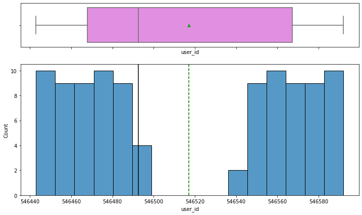

```python
## let us see general user visuals
histogram_boxplot(e_news,'user_id',bins = 16)
```

#### Observations:

- user_id is unique
- The user corresponds to users on the landing page
- The mean is greater than the median indicating right skewness

```python
e_news.loc[:,'language_preferred'].value_counts()
```

```
French     34
Spanish    34
English    32
Name: language_preferred, dtype: int64
```

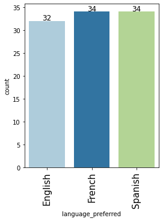

```python
labeled_barplot(e_news, 'language_preferred')
```

#### Observations:

- 34 Spanish users count and 34 French user count
- English language has 32 users as its language preferred

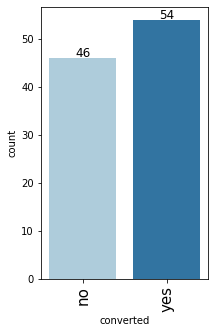

```python
labeled_barplot(e_news, 'converted')
```

#### Observations:

- In terms of count 54 users were converted and 46 were not converted

```python
e_news.loc[:,'landing_page'].value_counts()
```

```
new    50
old    50
Name: landing_page, dtype: int64
```

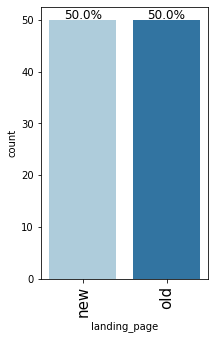

```python
labeled_barplot(e_news, 'landing_page', perc=True)
```

#### Observations:

- There are 2 unique landing pages, old and new
- Both new and old landing page are equal number of users

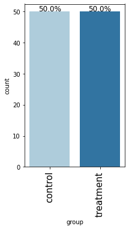

```python
labeled_barplot(e_news, 'group', perc=True)
```

#### Observations:

- There are 2 unique groups, control and treatment group
- The distribution shows that each group has 50% of users as mentioned in the background information

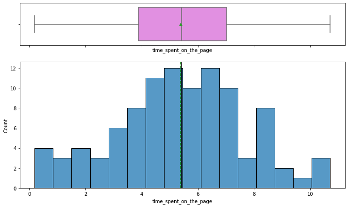

```python
histogram_boxplot(e_news, 'time_spent_on_the_page', bins = 16)
```

#### Observations:

- distribution is normal
- The mean and median time spent seems almost similar

### Performing bivariate/multivariate analysis to explore relationships between the important variables in the dataset.

```python
e_news['time_spent_on_the_page'][e_news['language_preferred'] == 'English'].mean()
```

```
5.559062500000001
```

```python
e_news['time_spent_on_the_page'][e_news['language_preferred'] == 'French'].mean()
```

```
5.253235294117649
```

```python
e_news['time_spent_on_the_page'][e_news['language_preferred'] == 'Spanish'].mean()
```

```
5.331764705882351
```

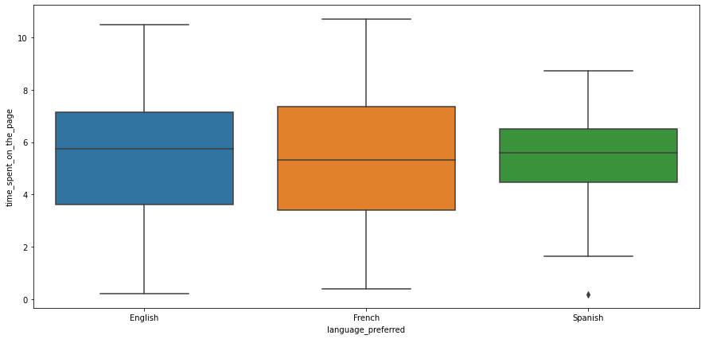

```python
# Relationship between language prefeered and time_spent_on_the_page
plt.figure(figsize=(15, 7))
sns.boxplot(x = 'language_preferred', y = 'time_spent_on_the_page', data = e_news)
plt.show()
```

#### Observations:

- Spanish language has an outlier
- The mean time spent on the page for all languages is similar and around the same time

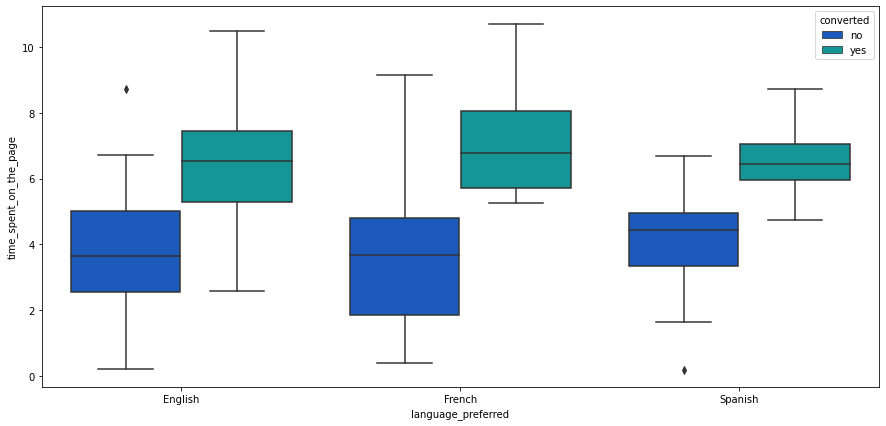

```python
# Relationship between language preferred and time_spent_on_the_page and converted
plt.figure(figsize=(15, 7))
sns.boxplot(e_news['language_preferred'],e_news['time_spent_on_the_page'], hue =e_news['converted'], palette = 'winter')
plt.show()
```

#### Observations:

- For all converted users, the time spent on the page is similar and above average time
- Spanish and English non converted user have an outlier
- language preferred does not seem like a good indicator for conversion rate.

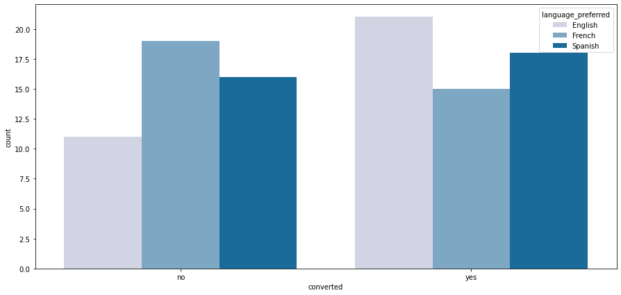

```python
plt.figure(figsize=(15, 7))
sns.countplot(e_news['converted'],hue=e_news['language_preferred'],palette ='PuBu').perc=True

plt.show()
```

#### Observations:

- It seems users whose preferred language is English are more likely to be converted than other languages
- Users with Spanish and French languages preferred also seem to be converted but to a lower degree thus language does not seem as a good indicator of conversion rate

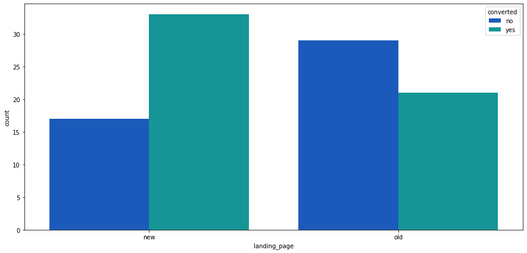

```python
plt.figure(figsize=(15, 7))
sns.countplot(e_news['landing_page'],hue=e_news['converted'],palette ='winter').perc=True

plt.show()
```

#### Observations:

- There are more converted subscribers on the new landing page than the old landing page
- The old landing page has a greater number of users not converted

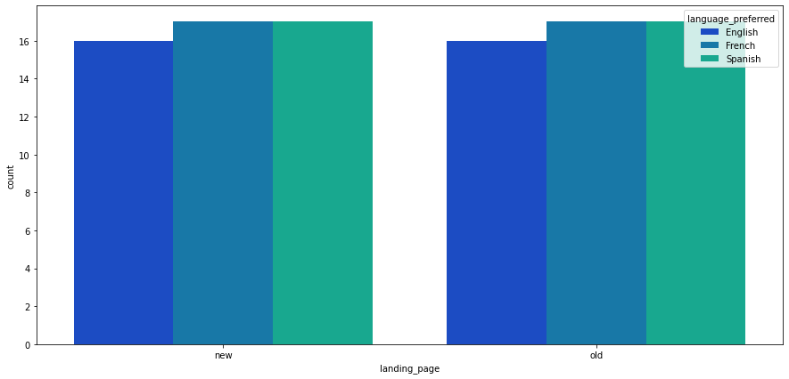

```python
plt.figure(figsize=(15, 7))
sns.countplot(e_news['landing_page'],hue=e_news['language_preferred'],palette ='winter').perc=True

plt.show()
```

#### Observations:

- Spanish and French both have the same preferred user number for both old and new landing page
- English preferred user is lower on both old and new landing page

```
Mean:  5.377800000000002
Median:  5.415
Mode:  0.4
```

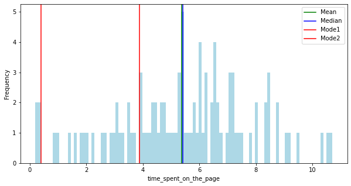

```python
### Descriptive stattistics of the mean, median and mode

mean=e_news['time_spent_on_the_page'].mean()
median=e_news['time_spent_on_the_page'].median()
mode=e_news['time_spent_on_the_page'].mode()

print('Mean: ',mean,'\nMedian: ',median,'\nMode: ',mode[0])

plt.figure(figsize=(10,5)) # set the figure size
plt.hist(e_news['time_spent_on_the_page'],bins=100,color='lightblue') #Plot the histogram

plt.axvline(mean,color='green',label='Mean')     # Draw lines on the plot for mean median and the two modes we have in GRE Score
plt.axvline(median,color='blue',label='Median')
plt.axvline(mode[0],color='red',label='Mode1')
plt.axvline(mode[1],color='red',label='Mode2')

plt.xlabel('time_spent_on_the_page')   # label the x-axis
plt.ylabel('Frequency')   # label the y-axis
plt.legend()              # Plot the legend
plt.show()
```

```python
mean=e_news['time_spent_on_the_page'].mean()
median=e_news['time_spent_on_the_page'].median()
mode=e_news['time_spent_on_the_page'].mode()

print('Mean: ',mean,'\nMedian: ',median,'\nMode: ',mode[0])
```

```
Mean:  5.377800000000002
Median:  5.415
Mode:  0.4
```

#### Observations:

```python
# using groupby function to find the total time spent on both old and new landing_page
e_news.groupby('landing_page')['time_spent_on_the_page'].sum()
```

```
landing_page
new    311.16
old    226.62
Name: time_spent_on_the_page, dtype: float64
```

#### Observations:

- Total time_spent_on_the_page for the new landing page is 311.16 mins
- A total of time_spent_on_the_page for the old landing page is 226.62 mins
- Total time spent on the new landing page is greater than the old landing page which mean more time was spent on the new page

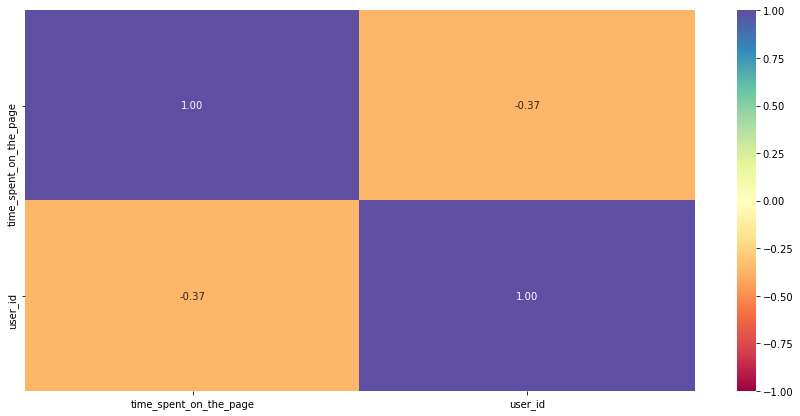

```python
# plot the heatmap
col_list = ['time_spent_on_the_page','user_id']

plt.figure(figsize=(15, 7))

sns.heatmap(e_news[col_list].corr(), annot=True, vmin=-1, vmax=1, fmt=".2f", cmap="Spectral")
plt.show()
```

### Observations

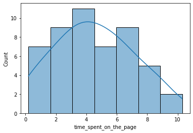

```python
sns.histplot(e_news[e_news['landing_page'] == 'old']['time_spent_on_the_page'], kde=True)
```

#### Observations:

- Distribution seems normal perhaps a larger sample size will provide more clarity

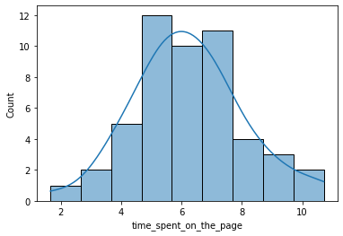

```python
sns.histplot(e_news[e_news['landing_page'] == 'new']['time_spent_on_the_page'], kde=True)
```

#### Observations:

- Distribution is normal

```python
# to find count of converted and not converted
e_news.loc[:,'converted'].value_counts()
```

```
yes    54
no     46
Name: converted, dtype: int64
```

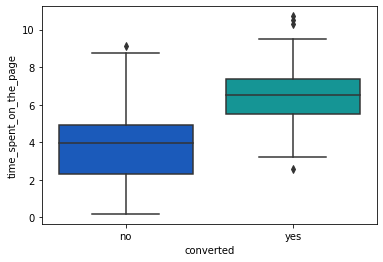

```python
sns.boxplot(x = 'converted',y = 'time_spent_on_the_page',data = e_news, palette="winter");
```

#### Observtions:

- It seems users whose time spent on the page was at least average got converted
- Not converted seem to spend less than the average time on the landing page
- There are outliers in the time spent for users who got converted

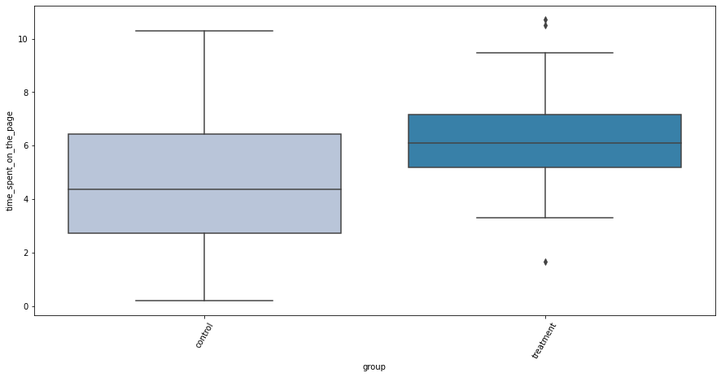

```python
# Relationship between groups and time_spent_on_the_page
plt.figure(figsize=(15,7))

sns.boxplot(x = "group", y = "time_spent_on_the_page", data = e_news, palette = 'PuBu')
plt.xticks(rotation = 60)
plt.show()
```

#### Observations:

- Treatment group have outliers
- Treatment group analyzed the new landing page and control group was for the old landing page
- We observe that treament group average time spent on the page is higher than control group

# Statistical Analysis and Insights

# 1. Do the users spend more time on the new landing page than the old landing page?

## Step 1: Define null and alternate hypotheses

$H_0:$ The mean output from the new landing page is equal to the mean output from the old landing page.

$H_a:$ The mean output from the new landing page is greater than the mean output from the old landing page.

Let $\mu_1$ and $\mu_2$ be the mean output from the new page and the mean output from the old page respectively.

Mathematically, the above formulated hypotheses can be written as:

$H_0: \mu_1 = \mu_2 $

$H_a: \mu_1 > \mu_2 $

## Step 2: Select Appropriate test

The case is a Two Independent Sample T-test for Equality of Means - Unequal Std Dev

## Step 3: Decide the significance level

As given in the problem statement, we select 𝛼 = 0.05.

Hint: If p-value > 0.05: Fail to reject the H0 ;

If p-value < 0.05: Reject H0

## Step 4:Collect and Prepare Data

```python
# Average time spent on each of the landing page
e_news.groupby('landing_page')['time_spent_on_the_page'].mean()
```

```
landing_page
new    6.2232
old    4.5324
Name: time_spent_on_the_page, dtype: float64
```

```python
time_spent_on_old = e_news[e_news['landing_page'] == 'old']['time_spent_on_the_page']
```

```python
time_spent_on_new = e_news[e_news['landing_page'] == 'new']['time_spent_on_the_page']
```

```python
# find the sample means and sample standard deviations for the two landing page

print('The mean time spent on the old landing page is ' + str(round(time_spent_on_old.mean(),2)))
print('The mean time spent on the new landing page is ' + str(round(time_spent_on_new.mean(),2)))
print('The standard deviation of time spent for the old landing page is ' + str(round(time_spent_on_old.std(),2)))
print('The standard deviation of time spent for the new landing page ' + str(round(time_spent_on_new.std(),2)))
```

```
The mean time spent on the old landing page is 4.53
The mean time spent on the new landing page is 6.22
The standard deviation of time spent for the old landing page is 2.58
The standard deviation of time spent for the new landing page 1.82
```

## Step 5: Calculate the p-value

```python
#import the required functions
from scipy.stats import ttest_ind

# find the p-value

test_stat, p_value = ttest_ind(time_spent_on_new,time_spent_on_old, equal_var = False, alternative = 'greater')

print('The p-value is ', p_value)
```

```
The p-value is  0.0001392381225166549
```

## Step 6: Compare the p-value with $\alpha$

```python
# print the conclusion based on p-value
if p_value < 0.05:
    print(f'As the p-value {p_value} is less than the level of significance, we reject the null hypothesis.')
else:
    print(f'As the p-value {p_value} is greater than the level of significance, we fail to reject the null hypothesis.')
```

```
As the p-value 0.0001392381225166549 is less than the level of significance, we reject the null hypothesis.
```

#### Let's test whether the T-test assumptions are satisfied or not

- Continuous data - The time spent on the page is measured on a continuous scale.
- Normally distributed populations or Sample sizes > 30. Since the sample sizes are greater than 30, Central Limit Theorem states that the distribution of sample means will be normal.
- Independent populations - As we are taking samples for two different landing page, the two samples are from two independent populations.
- Population standard deviation 𝜎1 and 𝜎2 not known - since the standard deviation are differnt we will assume different standard deviations of both the populations.
- Random sampling from the population - Yes, we are informed that the collected sample is a simple random sample.
- Voila! We can use two sample T-test for this problem.

## Step 7: Draw Inference

At 0.05 significance level, we reject the null hypothesis. Hence we have enough statistical evidence to say that users spend more time on the new landing page than the old landing page.

### Conclusions drawn from the test

- If we compare the means of the two sample distributions, we see that statistically we can reject the null hypothesis.
- The higher mean in the case of the new landing page can also be attributed to the higher outliers compared to Old landing page.
- The average time users spent on the new landing page could have contributed to the conversion rate unlike the old landing page where users spent less than the average time thus recorded a high mumber of non converted

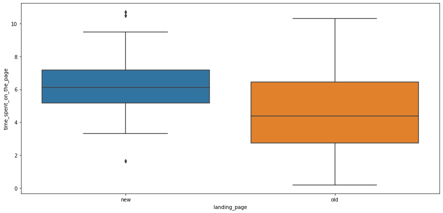

```python
# Visual Relationship between landing_page and time_spent_on_the_page
plt.figure(figsize=(15, 7))
sns.boxplot(x = 'landing_page', y = 'time_spent_on_the_page', data = e_news)
plt.show()
```

### Observations:

- Users spend more time on the new landing page
- The users spend more than the mean time spent on the new landing page which is above average
- Time spent on the page on the old landing page is below average

# 2. Is the conversion rate (the proportion of users who visit the landing page and get converted) for the new page greater than the conversion rate for the old page?

## Define the Null Hypothesis

𝐻0: The proportion of conversion rate for new page is equal to proportion of conversion rate for old page.

𝐻𝑎: The proportion of conversion rate for new page new page is greater than proportion of conversion rate for old page.

Let P1 and P2 be proportion of conversion rate for new page and old page respectively.

Mathematically, the above formulated hypotheses can be written as:

𝐻0: P1 = P2

against the alternative hypothesis

𝐻𝑎: P1 > P2

## Step 2: Select Appropriate test

We will use the Two proportions Z test

## Step 3: Decide the significance level

As given in the problem statement, we select 𝛼 = 0.05.

## Step 4: Collect and Prepare Data

```python
def getConversionRate(series):
    """
        Args: Series object -- The 'converted' field in this case.
        Action: Extracts the total number of users and conversions in each landing page.
        Returns: The conversion rate in each landing page
    """
    n = len(series)
    converted = len([x for x in series if x=='yes'])
    conversionRate = round(converted/n, 2) * 100


    return str(conversionRate)+'%'
```

```python
e_news.loc[:,'converted'].value_counts()
```

```
yes    54
no     46
Name: converted, dtype: int64
```

```python
e_news.groupby('landing_page')['converted'].apply(getConversionRate)
```

```
landing_page
new    66.0%
old    42.0%
Name: converted, dtype: object
```

#### Observations:

- The new landing page has a higher conversion proportion rate than the old landing page
- 66% for users who visit the new page were converted
- 42% of users who vist the page and were converted

```python
e_news = pd.read_csv('abtest.csv')
e_news.head(2)
```

|  | user_id | group | landing_page | time_spent_on_the_page | converted | language_preferred |
| --- | --- | --- | --- | --- | --- | --- |
| 0 | 546592 | control | old | 3.48 | no | Spanish |
| 1 | 546468 | treatment | new | 7.13 | yes | English |

```python
# Replace converted column with value count to draw some insights of the boolean condition

e_news.converted.replace({'yes':1, 'no':0}, inplace=True)
```

```python
# we need to find the conversion rate in each group using the z test. we will determine the std for each group

conversion_rates = e_news.groupby('group')['converted']

std_p = lambda x: np.std(x, ddof=0)              # Std. deviation of the proportion
se_p = lambda x: stats.sem(x, ddof=0)            # Std. error of the proportion (std / sqrt(n))

conversion_rates = conversion_rates.agg([np.mean, std_p, se_p])
conversion_rates.columns = ['conversion_rate', 'std_deviation', 'std_error']


conversion_rates.style.format('{:.3f}')
```

| group | conversion_rate | std_deviation | std_error |
| --- | --- | --- | --- |
| control | 0.420 | 0.494 | 0.070 |
| treatment | 0.660 | 0.474 | 0.067 |

#### Observations:

- Treatment group working on the new landing page have a higher conversion rate at 0.66
- The control group working on the old landing page have a lower conversion rate at 0.42

```python
e_news = pd.read_csv('abtest.csv')
e_news.head()
```

|  | user_id | group | landing_page | time_spent_on_the_page | converted | language_preferred |
| --- | --- | --- | --- | --- | --- | --- |
| 0 | 546592 | control | old | 3.48 | no | Spanish |
| 1 | 546468 | treatment | new | 7.13 | yes | English |
| 2 | 546462 | treatment | new | 4.40 | no | Spanish |
| 3 | 546567 | control | old | 3.02 | no | French |
| 4 | 546459 | treatment | new | 4.75 | yes | Spanish |

```python
# number of old landing page converted
old_page_con =e_news[e_news['landing_page']=='old']['converted'].value_counts()['yes']

# number of old landing page converted
new_page_con =e_news[e_news['landing_page']=='new']['converted'].value_counts()['yes']


print('The numbers of converted users from the old and new landing pages are {0} and {1} respectively'.format(old_page_con,new_page_con))

# number of users in old landing page
nob_old_page =e_news['landing_page'].value_counts()['old']

# number of users in new landing page
nob_new_page =e_news['landing_page'].value_counts()['new']


print ('The total number of old landing page and new landing page users are {0} and {1} respectively'.format(nob_old_page,nob_new_page))
```

```
The numbers of converted users from the old and new landing pages are 21 and 33 respectively
The total number of old landing page and new landing page users are 50 and 50 respectively
```

```python
print (f' The proportion of converted users from the old and new landing pages are {round(21/50,2)},{round(33/50,2)} respectively')
```

```
 The proportion of converted users from the old and new landing pages are 0.42,0.66 respectively
```

#### Observations:

- The proportion of converted users from the old landing page is 0.42
- The proportion of converted users from the new landing page is 0.66

### Let's test whether the Z-test assumptions are satisfied or not

- Binomally distributed population - Yes, users either get converted or not
- Random sampling from the population - Yes, a random sample was used for the testing
- Can the binomial distribution approximated to normal distribution - Yes. For binary data, CLT works slower than usual. The standard thing is to check whether np and n(1-p) are greater than or equal to 10. Here, n and p refer to the sample size and sample proportion respectively. $np_1 = 50\cdot \frac{33}{50} =33 \geq 10\\ n(1-p_1) = 50 \cdot \frac{50-33}{50} =17 \geq 10 \\ np_2 = 50\cdot \frac{21}{50} =21 \geq 10\\ n(1-p_2) = 50 \cdot \frac{50-21}{50} =29 \geq 10 $

## Step 5: Calculate the p-value

```python
# find the p-value
# import the required fuction
from statsmodels.stats.proportion import proportions_ztest

test_stat, p_value = proportions_ztest([new_page_con,old_page_con],
                                       [nob_new_page,nob_old_page],
                                       alternative = 'larger')
print('The p-value is ' + str(p_value))
```

```
The p-value is 0.008026308204056278
```

## Step 6: Compare the p-value with $\alpha$

```python
# print the conclusion based on p-value
if p_value < 0.05:
    print(f'As the p-value {p_value} is less than the level of significance, we reject the null hypothesis.')
else:
    print(f'As the p-value {p_value} is greater than the level of significance, we fail to reject the null hypothesis.')
```

```
As the p-value 0.008026308204056278 is less than the level of significance, we reject the null hypothesis.
```

#### Draw Inference

- As the p-value 0.008026308204056278 is less than the level of significance, we reject the null hypothesis.

#### Conclusions:

In this scenario, the p value is 0.008 which is less than the significance level of 0.05. Hence, we reject the null hypothesis.

- This means that we have enough statistical evidence to say that the conversion rate for the new landing page is greater than the old landing page for users who visted and got converted

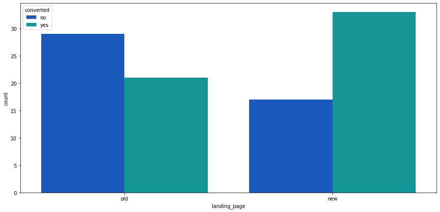

```python
# Visual representation of landing page and converted

plt.figure(figsize=(15,7))
sns.countplot(e_news["landing_page"],hue=e_news["converted"],palette='winter')
plt.show()
```

#### Observations:

- Most users who visted the new landing page were converted while the old landing page were not
- There seems to be more converted from the new landing page than the old landing page

# 3. Does the converted status depend on the preferred language? [Hint: Create a contingency table using the pandas.crosstab() function]

## Step 1 -Define the null and alternative hypothesis

We will test the null hypothesis

𝐻0: The converted status is independent on preferred language

Against the alternative hypothesis

𝐻𝑎: The converted status is Not independent on preferred language

## Step 2: Select Appropriate test

Chi-Square Test for Independence

## Step 3: Decide the significance level

As given in the problem statement, we select 𝛼 = 0.05.

## Step 4: Collect and prepare data

```python
### using a crosstab function on original dataset. perhaps a copy should have been used so that data is still intact
e_news = pd.read_csv('abtest.csv')

pd.crosstab(e_news['converted'],e_news['language_preferred'])
```

| language_preferred converted | English | French | Spanish |
| --- | --- | --- | --- |
| no | 11 | 19 | 16 |
| yes | 21 | 15 | 18 |

#### Observations:

- Users who prefer English language are most lkely to be converted
- there is a varying dregree for other languages who got converted too thus language preferred does not seem like a strong indicator for converted users

## Let's test whether the assumptions are satisfied or not

- Categorical variables - Yes
- Expected value of the number of sample observations in each level of the variable is at least 5 - Yes, the number of observations in each level is greater than 5.
- Random sampling from the population - Yes, we are informed that the collected sample is a simple random sample.

```python
# reset index for converted to be column

crosstab = pd.crosstab(index = e_news['converted'], columns = e_news['language_preferred'])

crosstab.reset_index(inplace =True)
crosstab
```

| language_preferred | converted | English | French | Spanish |
| --- | --- | --- | --- | --- |
| 0 | no | 11 | 19 | 16 |
| 1 | yes | 21 | 15 | 18 |

## Step 5: Calculate the p-value

```python
# import the required function
from scipy.stats import chi2_contingency

# find the p-value
chi, p_value, dof, expected = chi2_contingency(crosstab.drop('converted', axis = 1))
print('The p-value is', p_value)
```

```
The p-value is 0.21298887487543447
```

## Step 6: Compare the p-value with $\alpha$

```python
# print the conclusion based on p-value
if p_value < 0.05:
    print(f'As the p-value {p_value} is less than the level of significance, we reject the null hypothesis.')
else:
    print(f'As the p-value {p_value} is greater than the level of significance, we fail to reject the null hypothesis.')
```

```
As the p-value 0.21298887487543447 is greater than the level of significance, we fail to reject the null hypothesis.
```

#### Conclusion:

- As the p-value is greater than the significance level 0.05, we fail to reject the null hypothesis thus we do not have enough statistical evidence to say that converted rate has a relationship or depends on language preferred.They are independent of each other

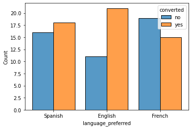

```python
# Visual reoresentation

sns.histplot(data=e_news,x = 'language_preferred', hue= 'converted',multiple='dodge',shrink=0.8)
```

#### Observations:

- We have converted users on all 3 preferred languages though english language seems to have the most converted users
- language preferred does not seem to be a good indicator for converted users

# 4. Is the mean time spent on the new page same for the different language users?

## Step 1: Let's write the null and alternative hypothesis

Let 𝜇1,𝜇2,𝜇3 be the means of language_preferred for English,French and Spanish respectively.

We will test the null hypothesis

𝐻0:𝜇1=𝜇2=𝜇3

against the alternative hypothesis

𝐻𝑎: At least one language_preferred is different from the rest.

## Step 2: Select Appropriate test

One-way ANOVA Test

## Step 3: Decide the significance level

As given in the problem statement, we select 𝛼 = 0.05.

## Step 4: Collect and Prepare data

```python
e_news.head()
```

|  | user_id | group | landing_page | time_spent_on_the_page | converted | language_preferred |
| --- | --- | --- | --- | --- | --- | --- |
| 0 | 546592 | control | old | 3.48 | no | Spanish |
| 1 | 546468 | treatment | new | 7.13 | yes | English |
| 2 | 546462 | treatment | new | 4.40 | no | Spanish |
| 3 | 546567 | control | old | 3.02 | no | French |
| 4 | 546459 | treatment | new | 4.75 | yes | Spanish |

```python
# get the levels of preferred language for the new page

e_news[e_news['landing_page']== 'new']['language_preferred'].value_counts()
```

```
French     17
Spanish    17
English    16
Name: language_preferred, dtype: int64
```

#### let us calculate mean time spent on the page for the preferred languages

```python
e_news['time_spent_on_the_page'][e_news['language_preferred'] == 'English'].mean()
```

```
5.559062500000001
```

```python
e_news['time_spent_on_the_page'][e_news['language_preferred'] == 'Spanish'].mean()
```

```
5.331764705882351
```

```python
e_news['time_spent_on_the_page'][e_news['language_preferred'] == 'French'].mean()
```

```
5.253235294117649
```

```python
newpage_users = e_news[e_news['landing_page']=='old']
newpage_users.groupby('language_preferred')['time_spent_on_the_page'].mean()
```

```
language_preferred
English    4.454375
French     4.310000
Spanish    4.828235
Name: time_spent_on_the_page, dtype: float64
```

```python
newpage_users = e_news[e_news['landing_page']=='new']
newpage_users.groupby('language_preferred')['time_spent_on_the_page'].mean()
```

```
language_preferred
English    6.663750
French     6.196471
Spanish    5.835294
Name: time_spent_on_the_page, dtype: float64
```

#### Observations:

- The mean time spent on the new page for different language users are seem similar
- English language has a mean time of 6.66mins, French is 6.19mins and Spanish is 5.83mins

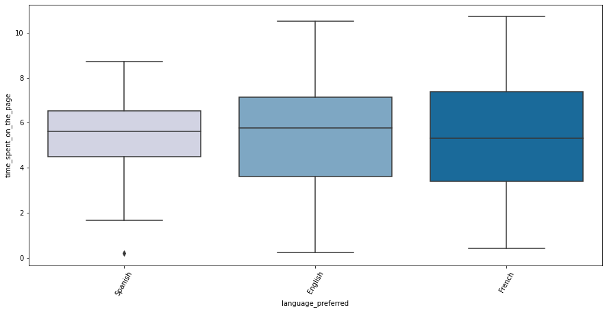

```python
# Visual Relationship between language_preferred and time_spent_on_the_page time
plt.figure(figsize=(15,7))

sns.boxplot(x = "language_preferred", y = "time_spent_on_the_page", data = e_news, palette = 'PuBu')
plt.xticks(rotation = 60)
plt.show()
```

### Observations:

- Spanish language has an outlier
- Mean language preferred are similar and around the same level

Now, the normality and equality of variance assumptions need to be checked.

- For testing of normality, Shapiro-Wilk’s test is applied to the response variable.
- For equality of variance, Levene test is applied to the response variable.

## Shapiro-Wilk’s test

We will test the null hypothesis

𝐻0: Time spent on the page follows a normal distribution against

against the alternative hypothesis

𝐻𝑎: Time spent on the page does not follow a normal distribution

```python
# Assumption 1: Normality
# import the required function
from scipy import stats

# find the p-value
w, p_value = stats.shapiro(e_news[e_news['landing_page'] == 'new']['time_spent_on_the_page'])
print('The p-value is ', p_value)
```

```
The p-value is  0.8040016293525696
```

```python
# print the conclusion based on p-value
if p_value < 0.05:
    print(f'As the p-value {p_value} is less than the level of significance, we reject the null hypothesis.')
else:
    print(f'As the p-value {p_value} is larger than the level of significance, we fail to reject the null hypothesis.')
```

```
As the p-value 0.8040016293525696 is larger than the level of significance, we fail to reject the null hypothesis.
```

#### Conclusion

- Since the p-value 0.80 is larger than the level of significance, we fail to reject the null hypothesis that the response follows the normal distribution.

## Levene’s test

We will test the null hypothesis

𝐻0 : All the population variances are equal

against the alternative hypothesis

𝐻𝑎 : At least one variance is different from the rest

```python
#Assumption 2: Homogeneity of Variance
#import the required function

from scipy.stats import levene

statistic, p_value = stats.levene(
                    e_news[(e_news['landing_page'] == 'new')&(e_news['language_preferred'] == 'English')]['time_spent_on_the_page'],
                    e_news[(e_news['landing_page'] == 'new')&(e_news['language_preferred'] == 'French')]['time_spent_on_the_page'],
                    e_news[(e_news['landing_page'] == 'new')&(e_news['language_preferred'] == 'Spanish')]['time_spent_on_the_page'])

# find the p-value
print('The p-value is', p_value)
```

```
The p-value is 0.46711357711340173
```

```python
# print the conclusion based on p-value

if p_value < 0.05:
    print(f'As the p-value {p_value} is less than the level of significance, we reject the null hypothesis.')
else:
    print(f'As the p-value {p_value} is larger than the level of significance, we fail to reject the null hypothesis.')
```

```
As the p-value 0.46711357711340173 is larger than the level of significance, we fail to reject the null hypothesis.
```

Since the p-value is large, we fail to reject the null hypothesis of homogeneity of variances.

#### Let's test whether the assumptions are satisfied or not

- The populations are normally distributed - Yes, the normality assumption is verified using the Shapiro-Wilk’s test.
- Samples are independent simple random samples - Yes, we are informed that the collected sample is a simple random sample.
- Population variances are equal - Yes, the homogeneity of variance assumption is verified using the Levene's test.

## Step 5: Calculate p-value

```python
#import the required function
from scipy.stats import f_oneway

# perform one-way anova test

statistic, p_value = stats.f_oneway(
                    e_news[(e_news['landing_page'] == 'new')&(e_news['language_preferred'] == 'English')]['time_spent_on_the_page'],
                    e_news[(e_news['landing_page'] == 'new')&(e_news['language_preferred'] == 'French')]['time_spent_on_the_page'],
                    e_news[(e_news['landing_page'] == 'new')&(e_news['language_preferred'] == 'Spanish')]['time_spent_on_the_page'])
print('The p-value is ' + str(p_value))
```

```
The p-value is 0.43204138694325955
```

## Step 6: Compare the p-value with $\alpha$

```python
# print the conclusion based on p-value
if p_value < 0.05:
    print(f'As the p-value {p_value} is less than the level of significance, we reject the null hypothesis.')
else:
    print(f'As the p-value {p_value} is greater than the level of significance, we fail to reject the null hypothesis.')
```

```
As the p-value 0.43204138694325955 is greater than the level of significance, we fail to reject the null hypothesis.
```

### Conclusion and Recommendations

### Conclusion from Exploratory Data Analysis

- 0.66 accounts for the proportion of users who visted the new landing page and got converted hence there are more converted users than not converted out of the sample size of 100 users
- A total number of 54 users were converted however the numbers of converted users from the old and new landing pages are 21 and 33 respectively
- Time spent on the page ranges from 0.19minutes to 10.71 minutes with a mean time spent of 4.53 minutes and 6.22 minutes on the old and new landing pages respectively
- Users spend more time on the new landing page than the old landing page and the average time spent is higher in the new landing page than the old landing page
- The language preferred did not seem like a good predictor for the converted users
- The converted users spent more time irrespective of their preferred language
- French and Spanish are the 2 most preferred languages
- The mean time spent on both old and new pages varied closely across the different languages
- The new landing page has a higher conversion rate than the old landing page
- Users whose time spent on the page above average seem to be converted than users who spent below the avarage time on the page

### Business Recommendations

Based on the statistical analysis carried out on the dataset, we can conclude the following following the hypothesis testing:

- E-news Express should consider implementing the new landing page to expand and acquire new subscribers
- The treatment group has enough statistical evidence to say why the business should implement the new landing page for business expansion and perhaps may carry out further analysis for future projection of success levels
- Statistically, we can infer that the business does not need to introduce new languages as language was not a good indicator to why users where converted on the page as we did not see any dependence of language and being converted.
- A few assumptions were made as we were not told of what the success rate for the business is and what the business was looking to achieve in terms of numbers for growth however we know that the new landing page of the two pages has a higher conversion rate so that is a starting point for the business
- It would be good to dig deeper as to why more time was spent on the new landing page than the old landing page thus more analysis is recommended in this regard
- Further analysis can be done to confirm if users once converted still spend the mean time on the page as this will help understand the pattern of users on the page
- It is recommended that analysis is done to find out the reason for spending time on the new page and what the real interest of users are
- Perhaps, all the above with a little enhancement of the new page from time to time will help to attract even more new subscribers